# Part 3; Tools for Reproducible (Open) Science

## The git/Github.com workflow; segregating data from compute infrastructure from code

[figure not shown]

## Just for kicks, a graph

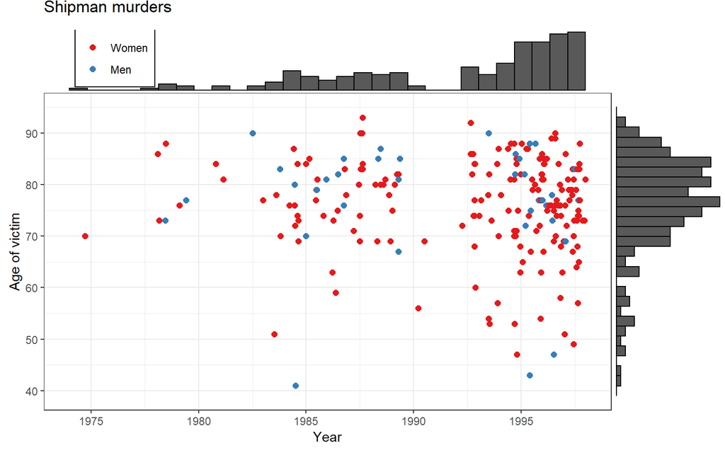

[Spiegelhalter, 2020, “The Art of Statistics”](https://github.com/dspiegel29/ArtofStatistics)

## Getting the code for all webinars into your RStudio environment; introducing the jargon

- **Get an Rstudio installation or account (via me)**
- **Clone the repo to your RStudio Env.**
- **Install any code dependencies in your Env.**
- **Run the code, and adapt if you want**
- *Work on the code*
- *Create a commit*
- *Create a pull request*

**LIVE DEMO**

## Github user-account

- https://github.com
- You can create personal and private repos
- Adding a README.md to each repo is a good idea
- The HU Github Data Science repos: https://github.com/uashogeschoolutrecht

## RStudio

- Integrated Development for R (and Python, Stan, C++, D3, SQL)
- Favorite IDE for using R
- Many integrated productivity tools (auto-completion, syntax highlighting, code-formatting, git-integrations, building tools)
- Send me an email if you want to use R/RStudio yourself!

## Getting Github-repo content in RStudio

- Copied url to Github repo on clipboard
- Open new RStudio Project
- Choose ‘Version Control’ Option
- Paste url from clipboard in url field
- Let the clone finish
- Start using the code!
- My code will work from a cloned github repo in an RStudio Project because of the [`{here}` package!](https://github.com/jennybc/here_here)

*Stop using `setwd()`!!!*

**LIVE DEMO**

## HU ResearchDrive

- Service brought to HU by SURF
- Application: https://bibliotheek.hu.nl/onderzoekers/datamanagement/
- Access though webinterfacte and other software
- SFTP software [CyberDuck](https://cyberduck.io/) (you need admin rights)
- Rclone (commandline interface)

## Which tool for what?

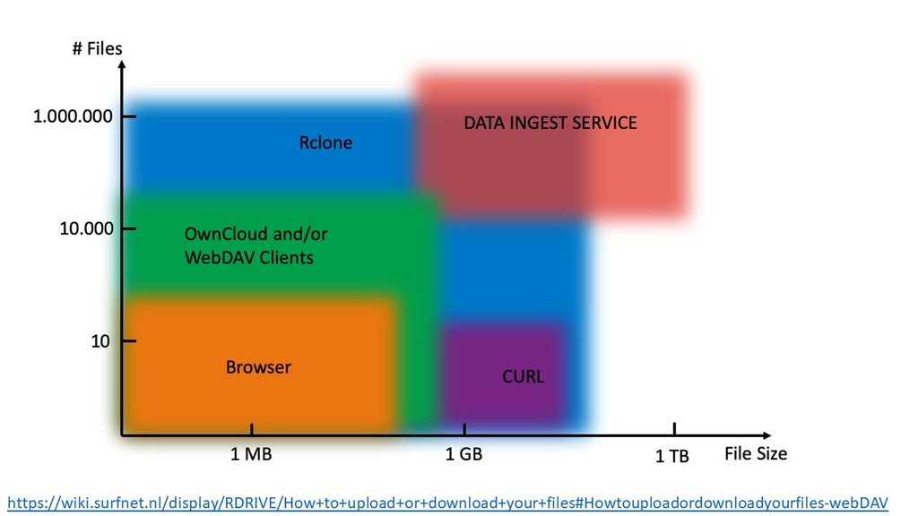

## Access HU-ResearchDrive from RStudio

To make this work you will need a WebDav token from HU ResearchDrive

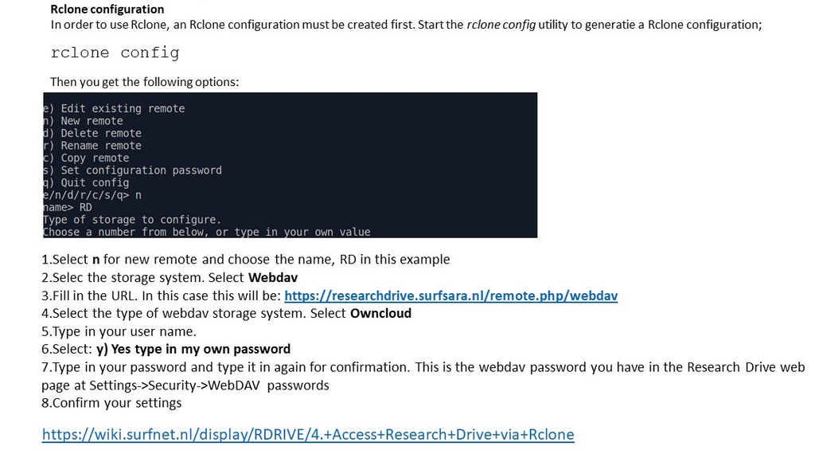

**Live Demo**

## Thank you for your attention!

[figure not shown]

**Ejoy the summer & Sta*R*t lea*R*ning:**

https://r4ds.had.co.nz/

https://rstudio.com/resources/webinars/

Find all the slides on: https://uashogeschoolutrecht.github.io/